# PISA 2012 Dataset Exploration

Now, let's check if the parent's education has a relationship with the mathematics anxiety:

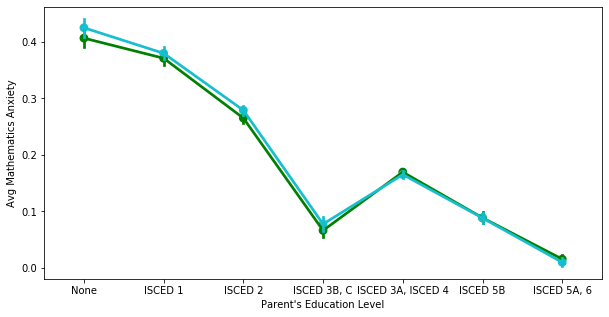

```python
# average mathematics anxiety versus parent's education
plt.figure(figsize=[10, 5])
sb.pointplot(data=pisa, x='FISCED', y='ANXMAT', color='green')
sb.pointplot(data=pisa, x='MISCED', y='ANXMAT', color=base_color)
plt.ylabel('Avg Mathematics Anxiety')
plt.xlabel('Parent\'s Education Level');
```

This is a very interesting insight: there is a downward trend that shows that the higher the education of the parents, the lower the mathematics anxiety.

We've seen earlier that the number of books at home relates to mathematics scores. Let's observe the relationship between the number of books and the level of parental education:

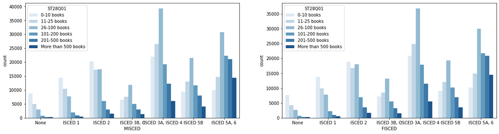

```python
plt.figure(figsize=[20, 5])
plt.subplot(1,2,1)
sb.countplot(data=pisa, x='MISCED', hue='ST28Q01', palette = 'Blues')
plt.subplot(1,2,2)
sb.countplot(data=pisa, x='FISCED', hue='ST28Q01', palette = 'Blues');
```

In the univariate exploration, we saw that the greatest group in term of number is "ISCED 3A, ISCED 4", closely followed by the group "ISCED 5A, 6". It is all the more interesting to observe that the last group have the most books at home (101-200 books / 201-500 books / more than 500 books).

Next let's observe the relationship between the home educational resources and the parent's level of education:

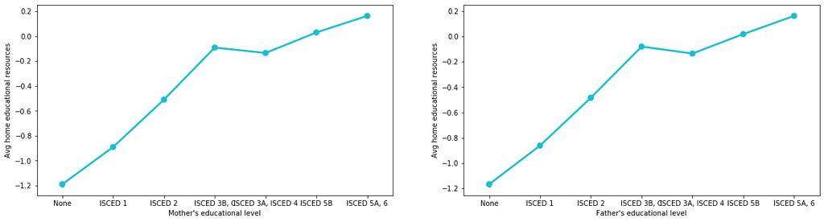

```python
# Home educational ressources versus parent's education level
plt.figure(figsize=[20, 5])
plt.subplot(1,2,1)
sb.pointplot(data=pisa, x='MISCED', y='HEDRES', color=base_color)
plt.ylabel('Avg home educational resources')
plt.xlabel('Mother\'s educational level')
plt.subplot(1,2,2)
sb.pointplot(data=pisa, x='FISCED', y='HEDRES', color=base_color)
plt.ylabel('Avg home educational resources')
plt.xlabel('Father\'s educational level');
```

There's here a clear trend upward: the higher the level of education, the more educational resources at home available.

Let's now have a look at the next variable: although mathematics anxiety and subjective Norms in Mathematics (SUBNORM) have almost no relationship (correlation: 0,064), let's have a closer look at the categorical variables belonging to SUBNORM:

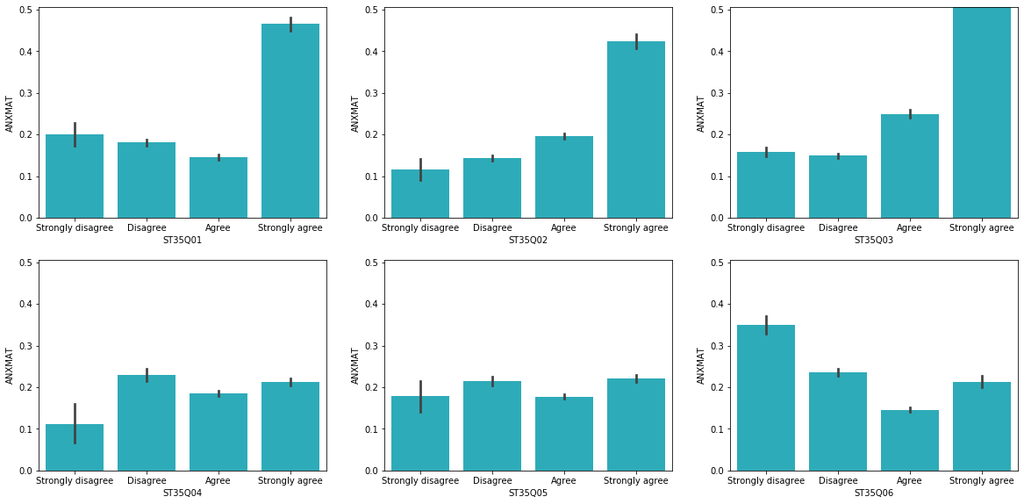

```python
# Comparison of subjective norms in mathematics versus average mathematics anxiety:
plt.figure(figsize=[20, 15])
plt.subplot(3, 3, 1)
sb.barplot(data=pisa, x='ST35Q01', y='ANXMAT', color=base_color) #Most of my friends do well in mathematics
ymin, ymax = plt.gca().get_ylim()
plt.ylim([ymin, ymax])
plt.subplot(3, 3, 2)
sb.barplot(data=pisa, x='ST35Q02', y='ANXMAT', color=base_color) #Most of my friends work hard at mathematics
plt.ylim([ymin, ymax])
plt.subplot(3, 3, 3)
sb.barplot(data=pisa, x='ST35Q03', y='ANXMAT', color=base_color) #My friends enjoy taking mathematics tests
plt.ylim([ymin, ymax])
plt.subplot(3, 3, 4)
sb.barplot(data=pisa, x='ST35Q04', y='ANXMAT', color=base_color) #My parents believe it’s important for me to study mathematics
plt.ylim([ymin, ymax])
plt.subplot(3, 3, 5)
sb.barplot(data=pisa, x='ST35Q05', y='ANXMAT', color=base_color) #My parents believe that mathematics is important for my career
plt.ylim([ymin, ymax])
plt.subplot(3, 3, 6)
sb.barplot(data=pisa, x='ST35Q06', y='ANXMAT', color=base_color) #My parents like mathematics
plt.ylim([ymin, ymax]);
```

Interestingly, we can observe that students with friends who have a positive attitude toward mathematics are on average more anxious than other students (Most of my friends do well in mathematics (ST35Q01), Most of my friends work hard at mathematics (ST35Q02) and My friends enjoy taking mathematics tests (ST35Q03)).  
Another interesting insight is that subjective norms regarding parents are not associated with an higher anxiety. (My parents believe it’s important for me to study mathematics (ST35Q04), My parents believe that mathematics is important for my career (ST35Q05) and My parents like mathematics (ST35Q06)).

### Conclusion of the bivariate exploration

Our bivariate exploration observed mainly two variables: mathematics scores and mathematics anxiety. It turned out that mathematics anxiety has a rather strong negative relationship to mathematics scores, so we observed the relationship of the anxiety with the other variables:

- Female students seem more anxious than male students
- The immigration status does not relate to the anxiety
- Extracurricular mathematics hours do not reduce mathematics anxiety
- The level of parental education seems to be related to mathematics anxiety: the higher the level of education, the lower the anxiety
- The student's anxiety seems to be higher when the student's friends have a positive attitude toward mathematics.

The other part of our bivariate exploration was observing the relationship of the main variable mathematics scores with other variables:

- Educational resources at home, like a desk or a quiet place to study, have a rather strong relationship with mathematics scores. The higher the level of education of the parents, the more educational resources at home available.
- Gender and immigration status have no relationship with mathematics scores
- The extracurricular mathematics hours do not relate to better mathematics scores
- The level of parental education seems to be related to mathematics scores: the higher the educational level, the better the mathematics scores
- The number of books at home have a relationship to the mathematics scores: the more books, the better the scores. Another visualization, comparing the number of books at home and the level of parental education, showed us that the highest level of education has the largest number of books at home.

It turned out that the variables interest in mathematics (INSTMAT), subjective norms in mathematics (SUBNORM) and instrumental motivation for mathematics (INSTMOT) have all strong relationship to one another. But since we are only interested in gaining insights into mathematics scores, we have excluded these 3 variables from our analysis.

## Multivariate Exploration

We want here to explore how variables play into the relationship between mathematics scores and mathematics anxiety.  
First, let's start with the educational resources at home:

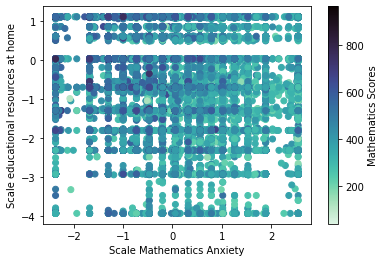

```python
# scatter plot educational ressources at home versus math anxiety versus math scores
plt.scatter(data = pisa, x='ANXMAT', y='HEDRES', c='PV1MATH', cmap='mako_r')
plt.xlabel('Scale Mathematics Anxiety')
plt.ylabel('Scale educational resources at home')
plt.colorbar(label='Mathematics Scores');
```

We can see that the best mathematics scores are located in the upper left area of the visualization. That is the area where students have the most educational resources at home and where the mathematics anxiety is weakest.

Next, let's take a look at the educational level of the parents:

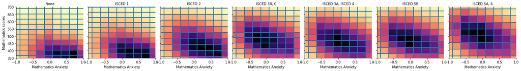

```python
# Mother's educational level vs math anxiety vs math scores
g = sb.FacetGrid(data = pisa, col = 'MISCED', col_wrap = 7, height = 3, margin_titles=True)
g.map(plt.hist2d, 'ANXMAT', 'PV1MATH', bins=[20, 20], cmap='magma_r')
g.set_titles("{col_name}")
g.set_axis_labels(x_var="Mathematics Anxiety", y_var="Mathematics scores")
plt.xlim(-1, 1)
plt.ylim(350, 700);
```

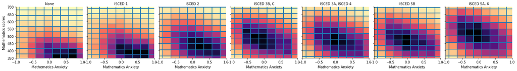

```python
# Father's educational level vs math anxiety vs math scores
g = sb.FacetGrid(data = pisa, col = 'FISCED', col_wrap = 7, height = 3)
g.map(plt.hist2d, 'ANXMAT', 'PV1MATH', bins=[20, 20], cmap='magma_r')
g.set_titles("{col_name}")
g.set_axis_labels(x_var="Mathematics Anxiety", y_var="Mathematics scores")
plt.xlim(-1, 1)
plt.ylim(350, 700);
```

As the level of education increases, the data 'migrates' from the lower right area of the visualization to the upper left area. This shows us that the higher the educational level of the parents, the higher the mathematics scores and the weaker the mathematics anxiety.

Let's have a look at the variable number of books at home:

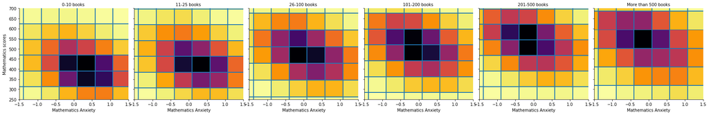

```python
# number of books at home vs math anxiety vs math scores
g = sb.FacetGrid(data = pisa, col = 'ST28Q01', col_wrap = 6, height = 4)
g.map(plt.hist2d, 'ANXMAT', 'PV1MATH', cmap='inferno_r')
g.set_titles("{col_name}")
g.set_axis_labels(x_var="Mathematics Anxiety", y_var="Mathematics scores")
plt.xlim(-1.5, 1.5)
plt.ylim(250, 700);
```

We have here the same trend as with the variable parent's educational level: the main data "migrates" from the lower right area of the visualization to the upper left area. This significates that the higher the number of books at home, the higher the mathematics scores and the lower the mathematics anxiety.

Next, let's compare our two variables mathematics scores and mathematics anxiety with the number of books at home and the mother's education level:

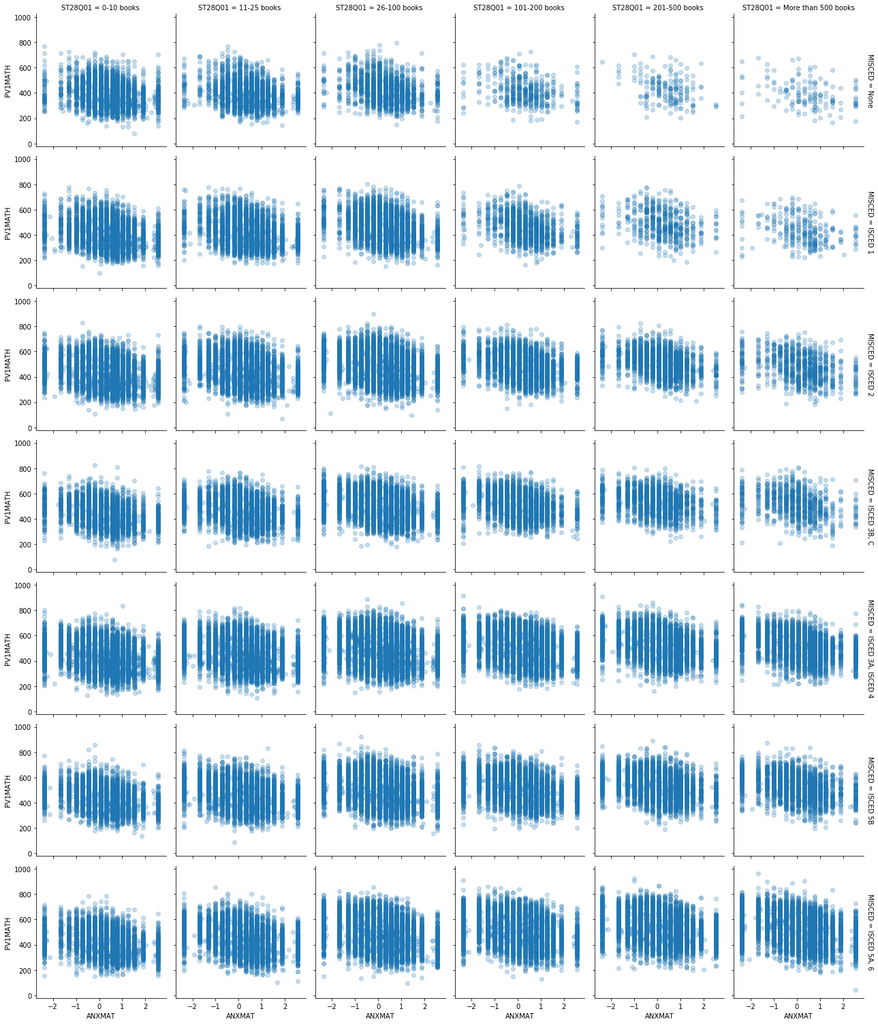

```python
# plot matrice comparing math scores, math anxiety, number of books at home and mother's education level
g = sb.FacetGrid(data = pisa, col='ST28Q01', row='MISCED', height=3, margin_titles=True)
g.map(plt.scatter, 'ANXMAT', 'PV1MATH', alpha=1/4);
```

All visualizations here are very similar. The relationship looks like negative in all plots: The lower the anxiety, the higher the mathematics scores. Mothers with no level of education or ISCED 1 have far fewer books at home than the other groups. The trend for mothers with level ISCED 5A, 6 isn't so clear, but we can still recognize that the number of dot in the column "More than 500 books" is higher than in in the column "0-10 books".

Since we already know the strong relationship between mathematics scores and mathematics anxiety, let's remove the variable mathematics anxiety and compare the average mathematics scores with the educational level and the number of books at home:

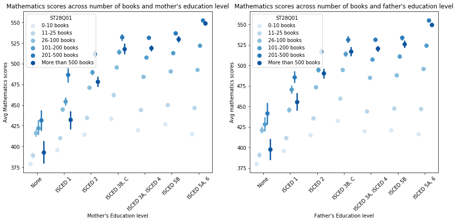

```python
# pointplot comparing math scores, parent's education level and number of books
fig, ax = plt.subplots(ncols = 2, figsize = [15,6])
sb.pointplot(data = pisa, x = 'MISCED', y = 'PV1MATH', hue = 'ST28Q01',
             palette = 'Blues', linestyles = '', dodge = 0.5, ax = ax[0])
ax[0].set_title('Mathematics scores across number of books and mother\'s education level')
ax[0].set_xticklabels(ax[0].get_xticklabels(), rotation=45)
ax[0].set_ylabel('Avg Mathematics scores')
ax[0].set_xlabel('Mother\'s Education level')

sb.pointplot(data = pisa, x = 'FISCED', y = 'PV1MATH', hue = 'ST28Q01',
             palette = 'Blues', linestyles = '', dodge = 0.5, ax = ax[1])
ax[1].set_title('Mathematics scores across number of books and father\'s education level')
ax[1].set_xticklabels(ax[1].get_xticklabels(), rotation=45)
ax[1].set_ylabel('Avg mathematics scores')
ax[1].set_xlabel('Father\'s Education level')

plt.show();
```

Here there is a clear upward trend: the parents with the highest number of books in the household belong to the highest education level group ISCED 5A, 6. Additionaly, this is the group in which students achiece the highest mathematics scores in average.  
However, it's interesting to note that these trends do not apply to the lowest educational levels of parents: if the parents have no education or level ISCED 1, a high number of books at home does not always have a positive relationship with the average mathematics results.

Lastly, let's compare the average mathematics anxiety with with the educational level and the number of books at home:

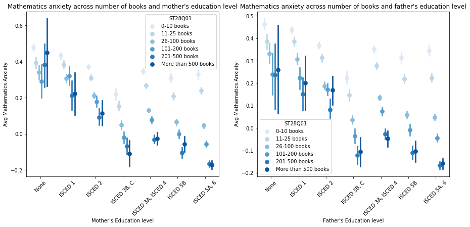

```python
# pointplot comparing math anxiety, parent's education level and number of books
fig, ax = plt.subplots(ncols = 2, figsize = [15,6])
sb.pointplot(data = pisa, x = 'MISCED', y = 'ANXMAT', hue = 'ST28Q01',
             palette = 'Blues', linestyles = '', dodge = 0.5, ax = ax[0])
ax[0].set_title('Mathematics anxiety across number of books and mother\'s education level')
ax[0].set_xticklabels(ax[0].get_xticklabels(), rotation=45)
ax[0].set_ylabel('Avg Mathematics Anxiety')
ax[0].set_xlabel('Mother\'s Education level')

sb.pointplot(data = pisa, x = 'FISCED', y = 'ANXMAT', hue = 'ST28Q01',
             palette = 'Blues', linestyles = '', dodge = 0.5, ax = ax[1])
ax[1].set_title('Mathematics anxiety across number of books and father\'s education level')
ax[1].set_xticklabels(ax[1].get_xticklabels(), rotation=45)
ax[1].set_ylabel('Avg Mathematics Anxiety')
ax[1].set_xlabel('Father\'s Education level')

plt.show();
```

At a low level of education, we can see that the average mathematics anxiety is the highest, with error bars increasing the higher the group representing the number of books at home. The mathematics anxiety is at lowest in the highest education level ISCED 5A, 6. We can also clearly see here, even at this highest educational level, if the number of books at home decreases, the average level of anxiety increases.  
However, this effect isn't so strong at a low level of education.

1) PISA DATA ANALYSIS MANUAL https://www.oecd-ilibrary.org/docserver/9789264056275-7-en.pdf?expires=1593104863&id=id&accname=guest&checksum=7823743D615762D34BB2F868F3193900  
2) PISA TECHNICAL REPORT https://www.oecd.org/pisa/pisaproducts/PISA-2012-technical-report-final.pdf